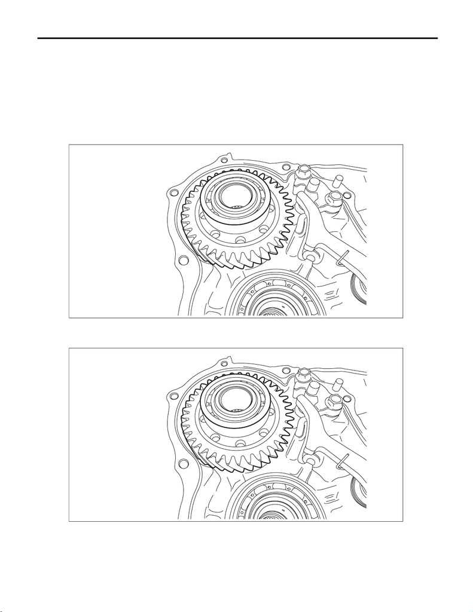

CVT(TR690)-158

Transfer Reduction Driven Gear

CONTINUOUSLY VARIABLE TRANSMISSION

32.Transfer Reduction Driven Gear

A: REMOVAL

1) Remove the transmission assembly from the vehicle. <Ref. to CVT(TR690)-56, REMOVAL, Automatic

Transmission Assembly.>

2) Remove the extension case. <Ref. to CVT(TR690)-142, REMOVAL, Extension Case.>

3) Remove the rear drive shaft. <Ref. to CVT(TR690)-146, REMOVAL, Rear Drive Shaft.>

4) Remove the transfer clutch assembly. <Ref. to CVT(TR690)-151, REMOVAL, Transfer Clutch.>

5) Remove the center differential carrier. <Ref. to CVT(TR690)-154, REMOVAL, Center Differential Carrier.>

6) Remove the transfer reduction driven gear assembly.

B: INSTALLATION

1) Install the reduction driven gear assembly.

2) Select shims. <Ref. to CVT(TR690)-161, ADJUSTMENT, Transfer Reduction Driven Gear.>

3) Install the center differential carrier. <Ref. to CVT(TR690)-155, INSTALLATION, Center Differential Car-

rier.>

4) Install the transfer clutch assembly. <Ref. to CVT(TR690)-151, INSTALLATION, Transfer Clutch.>

5) Install the rear drive shaft. <Ref. to CVT(TR690)-146, INSTALLATION, Rear Drive Shaft.>

AT-07363

AT-07363

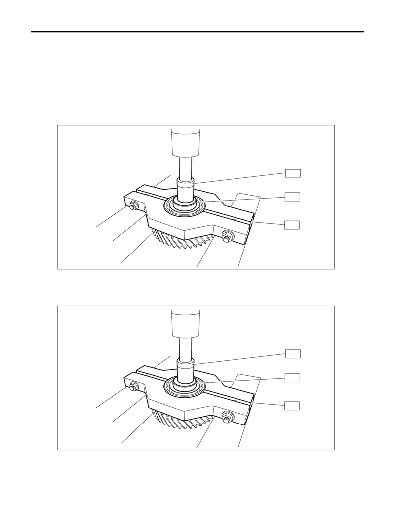

CVT(TR690)-159

Transfer Reduction Driven Gear

CONTINUOUSLY VARIABLE TRANSMISSION

6) Mount the selected shim onto ball bearing.

7) Install the extension case. <Ref. to CVT(TR690)-143, INSTALLATION, Extension Case.>

8) Install the transmission assembly to the vehicle. <Ref. to CVT(TR690)-69, INSTALLATION, Automatic

Transmission Assembly.>

C: DISASSEMBLY

1) Remove the snap ring from transfer reduction driven gear.

2) Using the ST, remove the ball bearing (large) from transfer reduction driven gear.

ST1 899864100 REMOVER

ST2 398497701 SEAT

ST3 498077600 REMOVER

3) Using the ST, remove the ball bearing (small) from transfer reduction driven gear.

ST1 899864100 REMOVER

ST2 398497701 SEAT

ST3 18720AA000 REMOVER

AT-05216

ST2

ST3

ST1

AT-05216

ST2

ST3

ST1

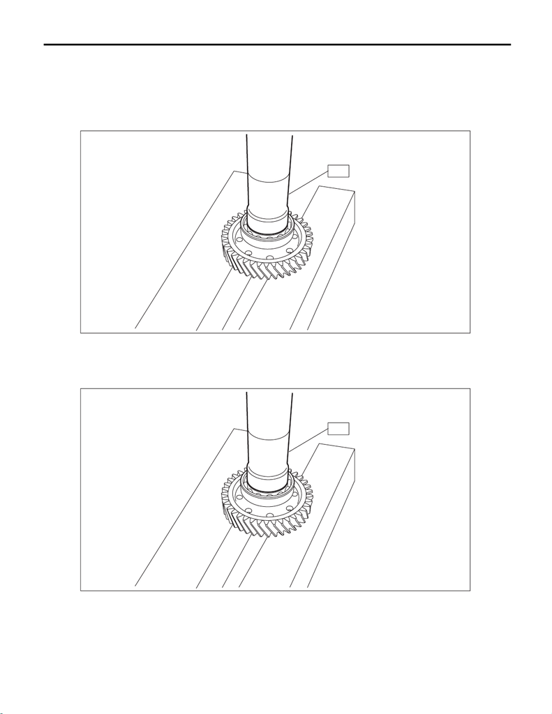

CVT(TR690)-160

Transfer Reduction Driven Gear

CONTINUOUSLY VARIABLE TRANSMISSION

D: ASSEMBLY

1) Install the new ball bearing (large) to reduction driven gear using the ST.

ST 499277100 BUSHING 1-2 INSTALLER

NOTE:

• Use a new ball bearing.

• Install to the splines inside transfer reduction driven gear shaft.

2) Install the new ball bearing (small) to reduction driven gear.

NOTE:

Use a new ball bearing.

ST 499277100 BUSHING 1-2 INSTALLER

3) Install the snap ring to transfer reduction driven gear.

E: INSPECTION

• Check the ball bearing for smooth rotation.

• Check the ball bearing for excessive looseness.

• Make sure the gear is not broken or damaged.

AT-05217

ST

AT-05217

ST

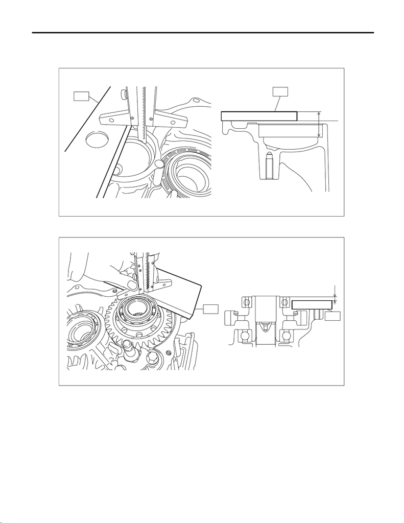

CVT(TR690)-161

Transfer Reduction Driven Gear

CONTINUOUSLY VARIABLE TRANSMISSION

F: ADJUSTMENT

1) Measure depth “A” from the ST upper face to the ball bearing catch surface.

ST 398643600 GAUGE

2) Measure height “B” from the ST to the end of the ball bearing outer ring.

ST 398643600 GAUGE

AT-07399

ST

A

ST

AT-07400

B

ST

ST

[figure not shown]

CVT(TR690)-162

Transfer Reduction Driven Gear

CONTINUOUSLY VARIABLE TRANSMISSION

3) Obtain the thickness of shim using the following formula to select one to three shims.

T mm = (A – 15) – (B + 15) + 0.38 – (0.05 — 0.25)

[T in = (A – 0.591) – (B + 0.591) + 0.0149 – (0.002 — 0.01)]

T: Shim thickness

A: Depth from the ST upper face to the ball bearing catch surface

B: Height from the ST to the end of the ball bearing outer ring

0.38 mm (0.0149 in): Thickness of gasket

15 mm (0.591 in): Thickness of ST

0.05 — 0.25 mm (0.002 — 0.01 in): Clearance

Shim

Part No. Thickness mm (in)

31288AA190 0.2 (0.008)

31288AA200 0.3 (0.012)

31288AA210 0.5 (0.02)